# Script to check accuracy and % of missing EUNIS for EVA and EVA Resurvey

# EUNIS level 1 availability

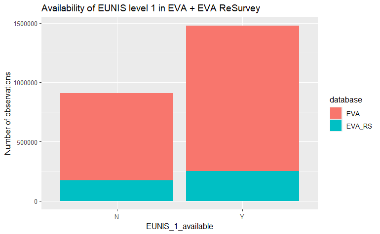

# EUNIS assignation

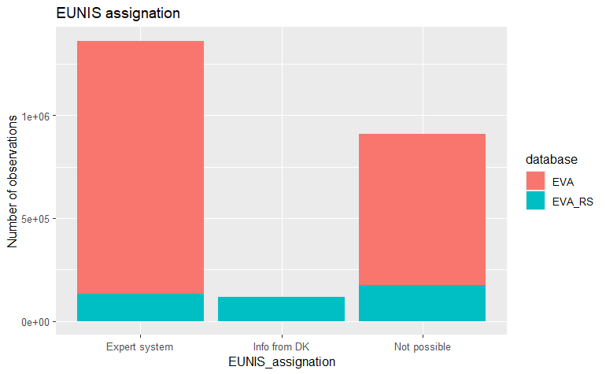

# Coordinates available

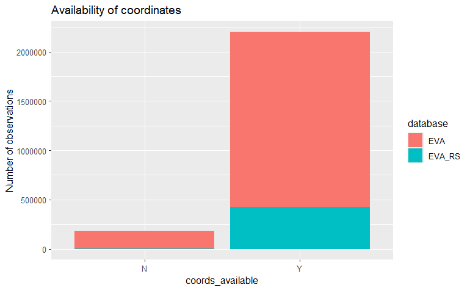

# Location uncertainty

## Availabilty

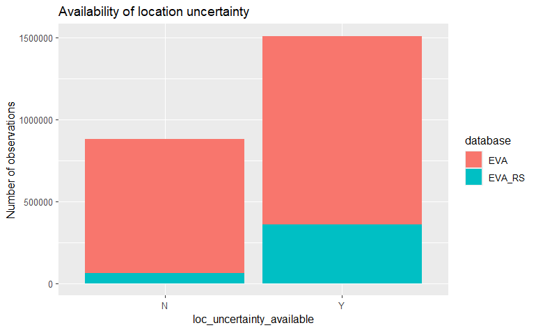

## Distribution when available

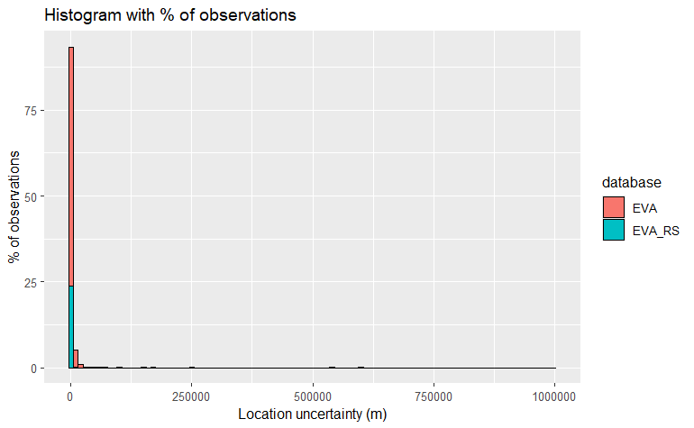

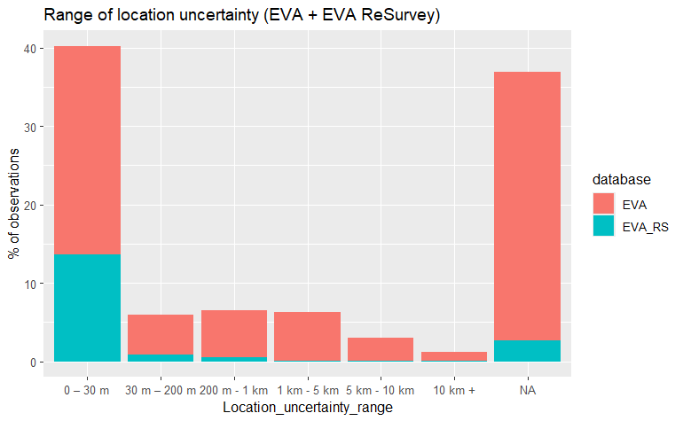

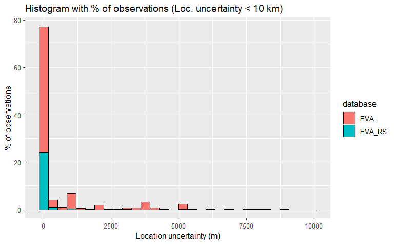

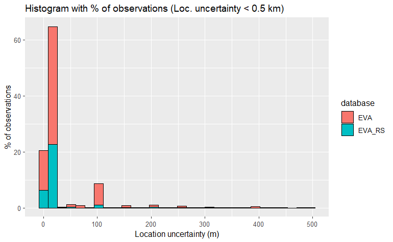

## Location method

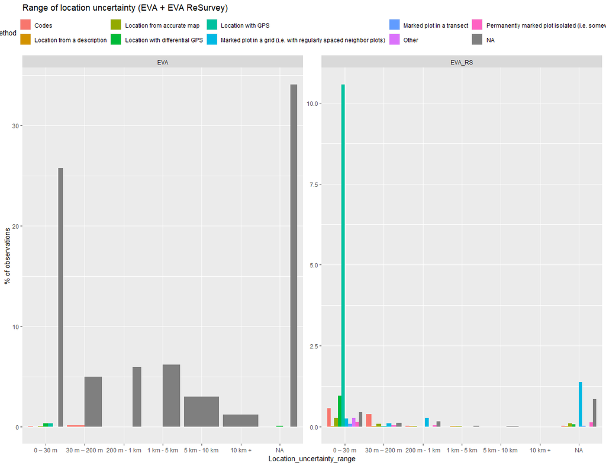

# Check for plots with multiple records for the same year

Careful! There are plots with muliple records for the same year (and sometimes same date).

For 6454 unique combinations of RS_CODE, ReSurvey site, ReSurvey plot and year, there are multiple records, sometimes with different dates within the year (OK - we choose one), **but also with the same exact date**.

Example below:

| PlotObservationID | RS_CODE | ReSurvey.site | ReSurvey.plot | year | date | count | Country | EUNISa | ReSurvey.project | ReSurvey.observation | Lon_updated | Lat_updated |
| --- | --- | --- | --- | --- | --- | --- | --- | --- | --- | --- | --- | --- |
| 748986 | CZ_0019_001 | N_Cep | N_Cep | 1952 | 1952-09-12 | 9 | Czech Republic | NA | TrebonFens | N_Cep_1_1952 | 14.83889 | 48.91944 |
| 748990 | CZ_0019_001 | N_Cep | N_Cep | 1952 | 1952-09-12 | 9 | Czech Republic | Q22 | TrebonFens | N_Cep_2_1952 | 14.83472 | 48.92083 |
| 748991 | CZ_0019_001 | N_Cep | N_Cep | 1952 | 1952-09-12 | 9 | Czech Republic | Q22 | TrebonFens | N_Cep_3_1952 | 14.83472 | 48.92083 |
| 748992 | CZ_0019_001 | N_Cep | N_Cep | 1952 | 1952-09-12 | 9 | Czech Republic | Q22 | TrebonFens | N_Cep_4_1952 | 14.83472 | 48.92083 |
| 748993 | CZ_0019_001 | N_Cep | N_Cep | 1952 | 1952-09-12 | 9 | Czech Republic | Q22 | TrebonFens | N_Cep_5_1952 | 14.82917 | 48.92222 |
| 749003 | CZ_0019_001 | N_Cep | N_Cep | 1952 | 1952-09-22 | 9 | Czech Republic | Q24 | TrebonFens | N_Cep_6_1952 | 14.83472 | 48.92083 |
| 749004 | CZ_0019_001 | N_Cep | N_Cep | 1952 | 1952-09-22 | 9 | Czech Republic | Q24 | TrebonFens | N_Cep_7_1952 | 14.83472 | 48.92083 |
| 749018 | CZ_0019_001 | N_Cep | N_Cep | 1952 | 1952-09-12 | 9 | Czech Republic | Q22 | TrebonFens | N_Cep_8_1952 | 14.83472 | 48.92083 |
| 749028 | CZ_0019_001 | N_Cep | N_Cep | 1952 | 1952-09-12 | 9 | Czech Republic | Q22 | TrebonFens | N_Cep_9_1952 | 14.83750 | 48.92083 |

I have sent a list to Ilona to see what to do with this issue.

# Keep GOOD observations WP3

Defining “good” observations as those that **have an EUNIS assigned** (any level) and where **location uncertainty is available and < 0.5 km** (decide if we use 0.2 or other value?).

From **EVA + EVA ReSurvey**, the **proportion of “good” observations** according to these criteria is **0.231**.

From **EVA ReSurvey only**, the **proportion of “good” observations** according to these criteria is **0.484**.

From **EVA + EVA ReSurvey**, the **proportion of observations with EUNIS assigned, irrespective of location uncertainty** is **0.619**.

From **EVA ReSurvey only**, the **proportion of observations with EUNIS assigned, irrespective of location uncertainty** is **0.59**.

Maybe include those without location uncertainty but where location method is GPS, etc.?

# Check for plots with multiple records for the same year in “good” observations

# Keep GOOD observations that do not have multiple records for the same year

From **EVA + EVA ReSurvey**, the **proportion of “good” observations** according to the above criteria **that do not have multiple records for the same year** is **0.226**.

From **EVA ReSurvey only**, the **proportion of “good” observations** according to the above criteria **that do not have multiple records for the same year** is **0.455**.

# Location uncertainty (last resurveys for EVA_RS)

Extract last resurvey for each each ReSurvey plot (defined by combination of RS_CODE, ReSurvey site and ReSurvey plot). So far, discard 111 resurvey observations corresponding to ReSurvey project “Swiss arable flora since the 1920s” (RS_CODE = CH_0002) where ReSurvey plot is NA. Discard also plots that have multiple records for the same year (if keeping those, we have to select one record - randomly?).

Check that there is only one record for each year for each plot: OK.

| RS_CODE | ReSurvey site | ReSurvey plot | year | count |
| --- | --- | --- | --- | --- |

## Availabilty

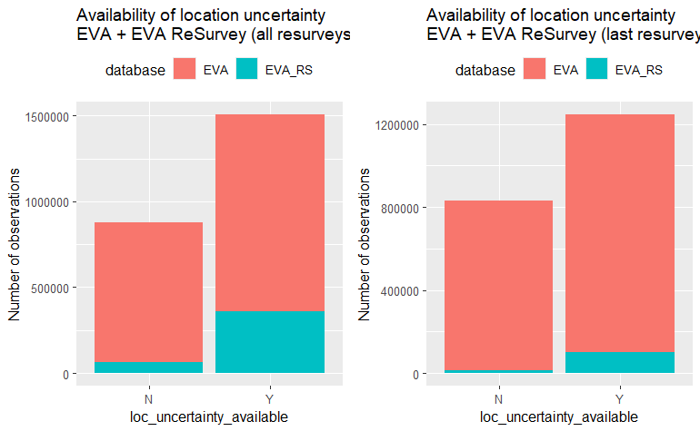

## Distribution when available

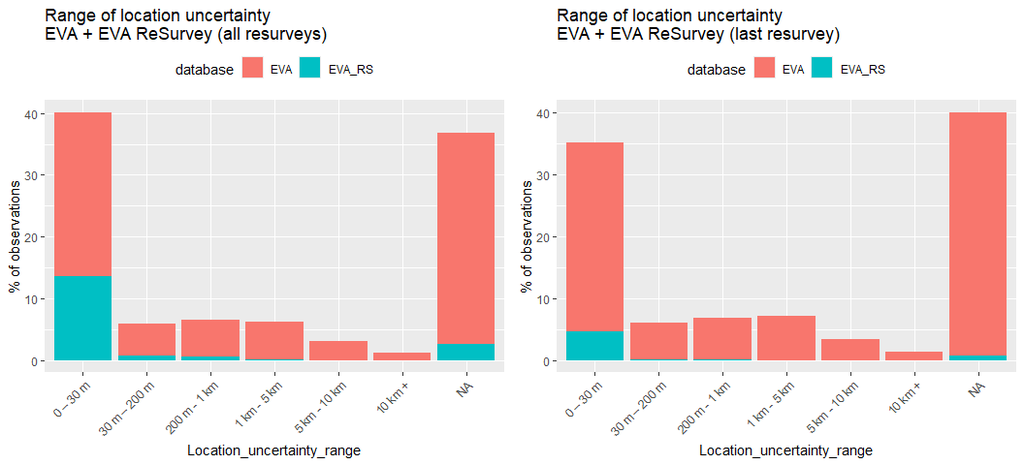

## Location method

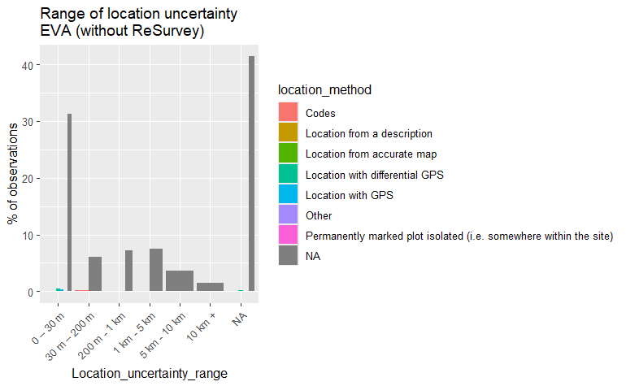

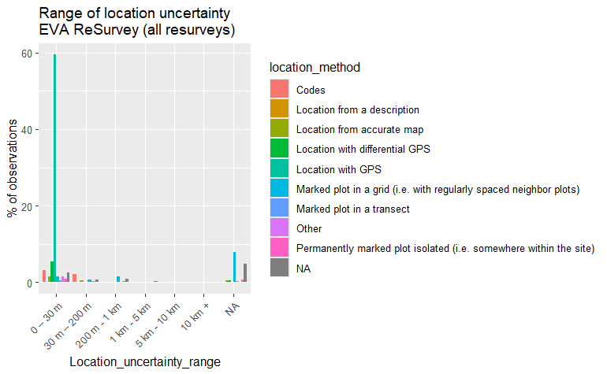

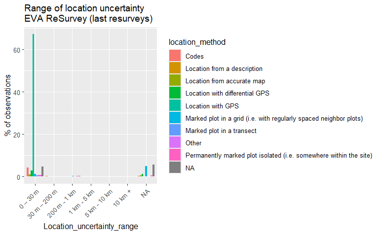